# 7 Statistical Models for Networks

Inferential approaches to network structure

Author

Dr Clemens Jarnach

Published

March 18, 2026

Descriptive measures tell us what networks look like; statistical models let us test hypotheses about *why* they look that way. This chapter introduces inferential frameworks for networks, focusing on **Exponential Random Graph Models (ERGMs)** — the workhorse of statistical network analysis in the social sciences.

## Why Standard Regression Fails for Networks

Before diving into ERGMs, it is worth understanding why we cannot simply regress a tie indicator (edge = 1, no edge = 0) on node or dyad attributes using OLS or logistic regression.

The core problem is **non-independence**. In standard regression, we assume that each observation is independent of every other. In a network, that assumption is violated almost by definition:

- Whether Alice is friends with Bob likely depends on whether Alice is friends with Carol, and whether Carol is friends with Bob (transitivity / triadic closure).
- A node with many friends is more likely to acquire *even more* friends (degree-based effects / preferential attachment).
- Ties between pairs of nodes are not drawn independently — the whole point of network analysis is that structure is relational and recursive.

If you ignore this and run a naive logistic regression on dyad-level tie indicators, your standard errors are likely wrong, and you may overstate statistical significance. The network is not a bag of independent coin flips — it is a *system*.

**Exponential Random Graph Models** (ERGMs, also called p* models) address this directly. An ERGM defines a probability distribution over the entire space of possible networks of a given size. It asks: given some set of network statistics (edge count, triangles, degree distribution, nodal covariates), what is the probability of observing *this particular network*?

Formally, an ERGM specifies:

$$P(Y = y) = \frac{\exp\left(\boldsymbol{\theta}^\top \mathbf{g}(y)\right)}{\kappa(\boldsymbol{\theta})}$$

where:

- $Y$ is the random network (each $Y_{ij}$ is a potential tie),
- $y$ is the observed network,
- $\mathbf{g}(y)$ is a vector of network statistics (e.g., number of edges, triangles, attribute-based counts),
- $\boldsymbol{\theta}$ is the corresponding vector of parameters to be estimated,
- $\kappa(\boldsymbol{\theta})$ is a normalising constant summing over *all possible networks* of the same size — which is what makes these models computationally demanding (and is why estimation uses MCMC).

Positive $\theta$ for a statistic means that networks with more of that feature are more likely than chance; negative means fewer. This gives us an intuitive, hypothesis-driven framework for asking: do triangles appear more often than we would expect at random? Do wealthy nodes preferentially connect to one another?

## Setup

```r
# Load only the statnet components needed for ERGMs
# (avoids dependency on tergm and other optional suite packages)
library(network)   # network objects
library(ergm)      # ERGM estimation and GoF
library(sna)       # network descriptives (gden, etc.)
library(ggplot2)   # for any custom plotting
```

## The Florentine Families Dataset

We will work with the **Florentine Families** dataset — a classic in social network analysis, first described by Padgett & Ansell (1993). It captures **marriage ties** among 16 prominent Florentine families in 15th-century Renaissance Italy. The Medici family’s rise to political dominance is a central story in the dataset: their strategic position in the marriage network gave them outsized influence.

The dataset is bundled with `ergm` (part of `statnet`) as `flomarriage`.

```r
# Load the dataset
# Load the florentine families data
data(florentine)
data(flomarriage)

# Inspect the network object
flomarriage
```

```
 Network attributes:
  vertices = 16
  directed = FALSE
  hyper = FALSE
  loops = FALSE
  multiple = FALSE
  bipartite = FALSE
  total edges= 20
    missing edges= 0
    non-missing edges= 20

 Vertex attribute names:
    priorates totalties vertex.names wealth

No edge attributes
```

```r
# Node-level attributes
flomarriage %v% "wealth"     # Annual income in thousands of lira (1427)
```

```
 [1]  10  36  55  44  20  32   8  42 103  48  49   3  27  10 146  48
```

```r
flomarriage %v% "priorates"  # Number of seats on city council 1282-1344
```

```
 [1] 53 65  0 12 22  0 21  0 53  0 42  0 38 35 74  0
```

```r
flomarriage %v% "vertex.names"
```

```
 [1] "Acciaiuoli"   "Albizzi"      "Barbadori"    "Bischeri"
 [5] "Castellani"   "Ginori"       "Guadagni"     "Lamberteschi"
 [9] "Medici"       "Pazzi"        "Peruzzi"      "Pucci"
[13] "Ridolfi"      "Salviati"     "Strozzi"      "Tornabuoni"
```

```r
# Basic network descriptives
network.size(flomarriage)        # Number of nodes
```

```
[1] 16
```

```r
network.edgecount(flomarriage)   # Number of edges
```

```
[1] 20
```

```r
gden(flomarriage)                # Density
```

```
[1] 0.1666667
```

The network has 16 nodes (families) and 20 marriage ties. With a density of roughly 0.17, ties are sparse — typical of elite social networks where strategic marriages were carefully chosen, not randomly distributed.

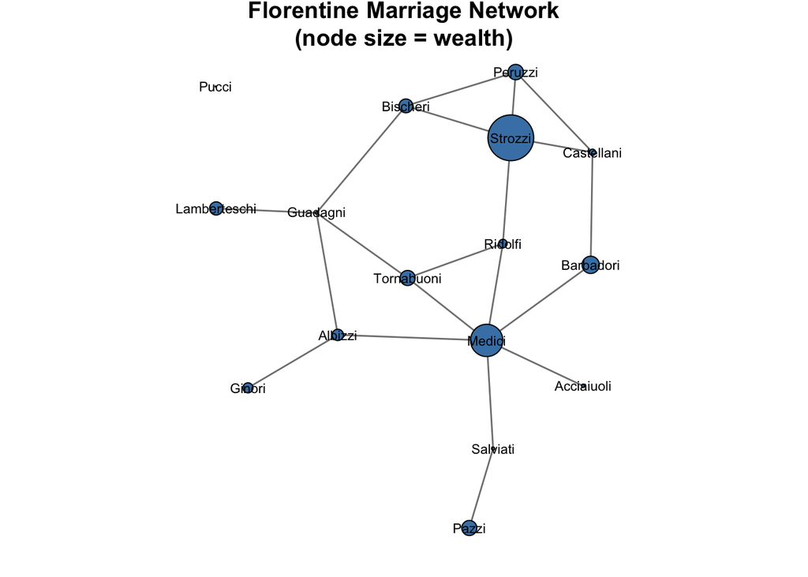

```r
# Visualise the network with wealth encoded in node size
par(mar = c(1, 1, 2, 1))

plot(
  flomarriage,
  vertex.cex    = flomarriage %v% "wealth" / 30,
  vertex.col    = "steelblue",
  edge.col      = "grey50",
  label         = flomarriage %v% "vertex.names",
  label.cex     = 0.7,
  label.pos     = 5,
  main          = "Florentine Marriage Network\n(node size = wealth)"
)
```

The Medici sit at the structural heart of this network. Despite not being the wealthiest family, they bridged otherwise disconnected clusters — a textbook example of brokerage and betweenness centrality translating into political power.

## Model 1: The Bernoulli (Null) Model

We start with the simplest possible ERGM: a **Bernoulli graph** or *Erdős–Rényi* model. The only term is `edges`, which acts like an intercept — it captures the baseline probability of a tie forming, and nothing else.

```r
model_null <- ergm(flomarriage ~ edges)
summary(model_null)
```

```
Call:
ergm(formula = flomarriage ~ edges)

Maximum Likelihood Results:

      Estimate Std. Error MCMC % z value Pr(>|z|)
edges  -1.6094     0.2449      0  -6.571   <1e-04 ***
---
Signif. codes:  0 '***' 0.001 '**' 0.01 '*' 0.05 '.' 0.1 ' ' 1

     Null Deviance: 166.4  on 120  degrees of freedom
 Residual Deviance: 108.1  on 119  degrees of freedom

AIC: 110.1  BIC: 112.9  (Smaller is better. MC Std. Err. = 0)
```

The coefficient for `edges` is negative, which makes sense: most possible ties are *absent* (the network is sparse). This log-odds can be converted to a probability:

```r
# Tie probability under null model
plogis(coef(model_null)["edges"])
```

```
    edges
0.1666667
```

This matches the network density exactly — as it should. The null model is just a fancy way of saying “each tie forms independently with probability equal to the overall density.” It is our baseline: every more complex model will be judged against it.

## Model 2: Structural Effects — Transitivity and GWESP

Real social networks are not Bernoulli. One of the most robust findings in network science is **triadic closure**: if A is tied to B, and B is tied to C, then A and C are more likely to be tied too. Friends of friends become friends. In the Florentine context: if the Medici married into the Tornabuoni *and* the Tornabuoni are linked to the Strozzi, the Medici-Strozzi tie becomes more likely.

The naive way to capture this is the `triangle` term — counting the number of closed triangles in the network. However, `triangle` is notorious for causing **model degeneracy**: the ERGM collapses onto a near-complete or near-empty graph, producing nonsensical estimates. This is a known pathology of the raw triangle term.

The solution is the **Geometrically Weighted Edgewise Shared Partners** (GWESP) statistic, introduced by Hunter & Handcock (2006). GWESP counts shared partners but applies a geometric decay: the *first* shared partner between a dyad contributes fully, the *second* contributes less, and so on. This prevents the model from being dominated by a few highly-triangulated nodes and greatly improves stability.

```r
model_structural <- ergm(
  flomarriage ~ edges + triangle + gwesp(0.5, fixed = TRUE),
  control = control.ergm(seed = 42)
)
summary(model_structural)
```

```
Call:
ergm(formula = flomarriage ~ edges + triangle + gwesp(0.5, fixed = TRUE),
    control = control.ergm(seed = 42))

Monte Carlo Maximum Likelihood Results:

                Estimate Std. Error MCMC % z value Pr(>|z|)
edges            -1.7666     0.3811      0  -4.635   <1e-04 ***
triangle         -2.3475     4.8488      0  -0.484    0.628
gwesp.fixed.0.5   1.0522     1.8857      0   0.558    0.577
---
Signif. codes:  0 '***' 0.001 '**' 0.01 '*' 0.05 '.' 0.1 ' ' 1

     Null Deviance: 166.4  on 120  degrees of freedom
 Residual Deviance: 107.6  on 117  degrees of freedom

AIC: 113.6  BIC: 122  (Smaller is better. MC Std. Err. = 0.02477)
```

> **Note on `triangle`:** Including `triangle` alongside `gwesp` is illustrative here — in practice you would typically use one or the other (preferring `gwesp`). If you encounter degeneracy warnings, drop `triangle` and rely solely on `gwesp`.

```r
# Fit GWESP-only structural model (more stable)
model_gwesp <- ergm(
  flomarriage ~ edges + gwesp(0.5, fixed = TRUE),
  control = control.ergm(seed = 42)
)
summary(model_gwesp)
```

```
Call:
ergm(formula = flomarriage ~ edges + gwesp(0.5, fixed = TRUE),
    control = control.ergm(seed = 42))

Monte Carlo Maximum Likelihood Results:

                Estimate Std. Error MCMC % z value Pr(>|z|)
edges           -1.66281    0.38595      0  -4.308   <1e-04 ***
gwesp.fixed.0.5  0.06435    0.27643      0   0.233    0.816
---
Signif. codes:  0 '***' 0.001 '**' 0.01 '*' 0.05 '.' 0.1 ' ' 1

     Null Deviance: 166.4  on 120  degrees of freedom
 Residual Deviance: 108.0  on 118  degrees of freedom

AIC: 112  BIC: 117.6  (Smaller is better. MC Std. Err. = 0.009081)
```

A positive and significant `gwesp` coefficient would tell us that triadic closure is a real force in this network — dyads that share at least one partner are more likely to be tied. However, the results are not statistical significant, so we may need to dig deeper.

## Model 3: Homophily — Does Wealth Drive Tie Formation?

Network structure is shaped not only by internal dynamics (transitivity, degree) but also by **node attributes**. A key question for the Florentine data: did wealthier families preferentially form marriage ties?

We test two hypotheses:

1. **Wealth activity effect** (`nodecov`): Do wealthier families have *more ties in general*? A positive `nodecov` coefficient means that nodes with higher wealth values are more likely to be involved in any given dyad being a tie.
2. **Wealth homophily** (`absdiff`): Do families of *similar wealth* preferentially marry one another? The `absdiff` term computes the absolute difference in wealth between each pair of nodes; a *negative* coefficient would indicate homophily (smaller differences → more ties).

```r
model_wealth <- ergm(
  flomarriage ~ edges + gwesp(0.5, fixed = TRUE) + nodecov("wealth") + absdiff("wealth"),
  control = control.ergm(seed = 42)
)
summary(model_wealth)
```

```
Call:
ergm(formula = flomarriage ~ edges + gwesp(0.5, fixed = TRUE) +
    nodecov("wealth") + absdiff("wealth"), control = control.ergm(seed = 42))

Monte Carlo Maximum Likelihood Results:

                 Estimate Std. Error MCMC % z value Pr(>|z|)
edges           -2.502124   0.583978      0  -4.285   <1e-04 ***
gwesp.fixed.0.5 -0.024287   0.274399      0  -0.089    0.929
nodecov.wealth   0.004649   0.006870      0   0.677    0.499
absdiff.wealth   0.011303   0.008852      0   1.277    0.202
---
Signif. codes:  0 '***' 0.001 '**' 0.01 '*' 0.05 '.' 0.1 ' ' 1

     Null Deviance: 166.4  on 120  degrees of freedom
 Residual Deviance: 101.5  on 116  degrees of freedom

AIC: 109.5  BIC: 120.7  (Smaller is better. MC Std. Err. = 0.005503)
```

Interpreting the results:

- A positive `nodecov("wealth")` suggests wealthier families are more active in forming ties overall.
- A negative `absdiff("wealth")` would indicate wealth homophily — families with similar wealth are drawn together.
- We evaluate statistical significance through the z-scores (estimate / std. error) and p-values in the summary output.

## Model Comparison: AIC and BIC

With multiple models in hand, we need a principled basis for comparison. **AIC** (Akaike Information Criterion) and **BIC** (Bayesian Information Criterion) penalise model complexity to guard against overfitting: lower is better.

```r
# Extract AIC and BIC for each model
model_list <- list(
  Null       = model_null,
  GWESP      = model_gwesp,
  Wealth     = model_wealth
)

comparison_table <- data.frame(
  Model  = names(model_list),
  AIC    = sapply(model_list, AIC),
  BIC    = sapply(model_list, BIC),
  LogLik = sapply(model_list, logLik)
)

comparison_table
```

```
        Model      AIC      BIC    LogLik
Null     Null 110.1347 112.9222 -54.06735
GWESP   GWESP 112.0071 117.5821 -54.00357
Wealth Wealth 109.5343 120.6843 -50.76716
```

```r
# Tidy comparison with knitr (renders nicely in HTML)
knitr::kable(
  comparison_table,
  digits  = 2,
  caption = "Model comparison: Florentine marriage network ERGMs"
)
```

Model comparison: Florentine marriage network ERGMs

|  | Model | AIC | BIC | LogLik |
| --- | --- | --- | --- | --- |
| Null | Null | 110.13 | 112.92 | -54.07 |
| GWESP | GWESP | 112.01 | 117.58 | -54.00 |
| Wealth | Wealth | 109.53 | 120.68 | -50.77 |

A model with substantially lower AIC/BIC than the null model would suggest that the added structural or covariate terms meaningfully improve fit beyond what chance predicts.

In our example, the wealth covariates provide the only substantive improvement in fit (log-likelihood gain of ~3.3), and AIC marginally favours including them; but the effect is small. Moreover, GWESP does essentially nothing here. Triadic closure may simply not be a strong structural force in this small, sparse network, or, the likely reason here, the network is too small to estimate it reliably. BIC’s preference for the Null is largely a function of the tiny sample (n = 16, 20 edges) — BIC is very conservative in small networks. The honest conclusion: with 16 nodes, you do not have the statistical power to decisively distinguish these models on AIC/BIC alone.

## MCMC Diagnostics

ERGMs are estimated using **Markov Chain Monte Carlo (MCMC)**. The MCMC sampler proposes changes to a simulated network and accepts or rejects them to approximate the normalising constant $\kappa(\boldsymbol{\theta})$ that cannot be computed analytically.

Before trusting your estimates, you *must* check that the MCMC chains have converged. A non-converged chain means the parameter estimates are unreliable, regardless of how significant the z-scores look.

`mcmc.diagnostics()` produces trace plots and autocorrelation diagnostics for each parameter. What you want to see:

- **Trace plots** that look like “fuzzy caterpillars” — bouncing randomly around a stable mean with no obvious trends or drift.
- **Low autocorrelation** — the chain is mixing well and not getting stuck.
- **Sample statistics close to observed** — the mean of the simulated statistics should match the observed statistics.

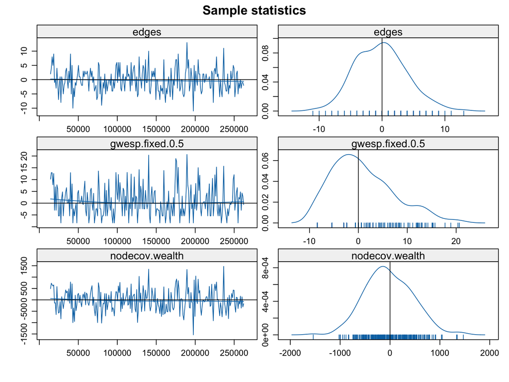

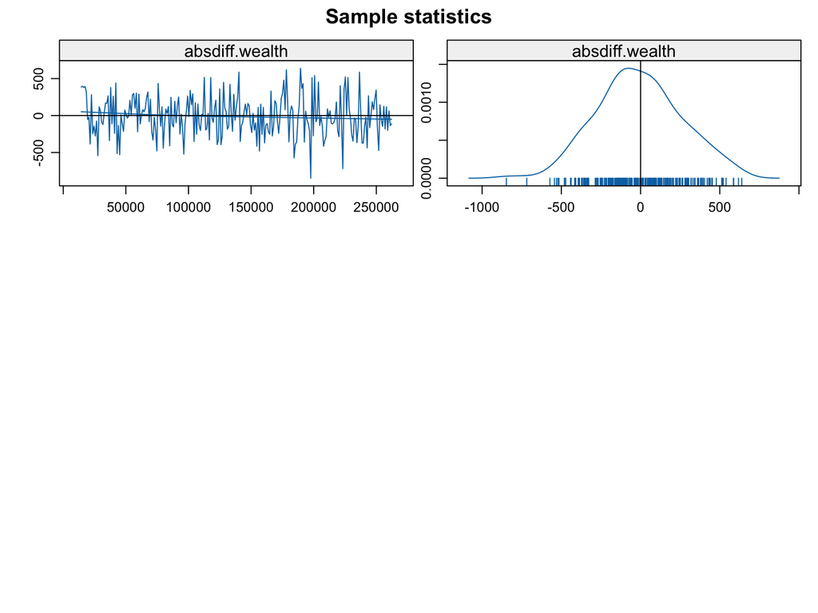

```
Sample statistics summary:

Iterations = 14336:262144
Thinning interval = 1024
Number of chains = 1
Sample size per chain = 243

1. Empirical mean and standard deviation for each variable,
   plus standard error of the mean:

                    Mean      SD Naive SE Time-series SE
edges            -0.1646   4.072   0.2612         0.2936
gwesp.fixed.0.5   0.9282   6.405   0.4109         0.4586
nodecov.wealth  -22.3704 479.054  30.7313        30.7313
absdiff.wealth   -8.5761 268.982  17.2552        17.2552

2. Quantiles for each variable:

                    2.5%    25%        50%     75%  97.5%
edges             -7.000   -3.0  0.000e+00   2.000   8.00
gwesp.fixed.0.5   -8.393   -3.0 -1.963e-13   4.787  15.16
nodecov.wealth  -916.200 -358.5 -6.700e+01 300.500 905.30
absdiff.wealth  -513.300 -188.0 -2.100e+01 164.000 515.95


Are sample statistics significantly different from observed?
                edges gwesp.fixed.0.5 nodecov.wealth absdiff.wealth
diff.      -0.1646091      0.92820257    -22.3703704     -8.5761317
test stat. -0.5606455      2.02400991     -0.7279333     -0.4970176
P-val.      0.5750392      0.04296913      0.4666544      0.6191766
                 (Omni)
diff.                NA
test stat. 2.495732e+01
P-val.     9.881306e-05

Sample statistics cross-correlations:
                    edges gwesp.fixed.0.5 nodecov.wealth
edges           1.0000000       0.8023854      0.8929658
gwesp.fixed.0.5 0.8023854       1.0000000      0.7939204
nodecov.wealth  0.8929658       0.7939204      1.0000000
```

[output cut: 24 more lines]

```
      0.7856964       1.2235716       0.6996823       0.5879705

Individual P-values (lower = worse):
          edges gwesp.fixed.0.5  nodecov.wealth  absdiff.wealth
      0.4320454       0.2211139       0.4841258       0.5565521
Joint P-value (lower = worse):  0.7542335

Note: MCMC diagnostics shown here are from the last round of
  simulation, prior to computation of final parameter
  estimates. Because the final estimates are refinements of
  those used for this simulation run, these diagnostics may
  understate model performance. To directly assess the
  performance of the final model on in-model statistics,
  please use the GOF command: gof(ergmFitObject,
  GOF=~model).
```

```r
mcmc.diagnostics(model_wealth)
```

If you see systematic drift, poor mixing, or large discrepancies between simulated and observed statistics, you may need to adjust MCMC settings (longer chains, thinner, more burnin) via `control.ergm()`.

## Goodness of Fit

Even if MCMC has converged, we need to check whether the model actually *fits* the observed network. **Goodness of Fit (GoF)** works as follows:

1. Simulate a large number of networks from the fitted ERGM.
2. Compute key network statistics for each simulated network.
3. Compare those distributions to the corresponding statistics of the *observed* network.

If the observed statistics fall within the bulk of the simulated distribution, the model fits. If they fall in the tails, the model is missing something important.

The standard GoF diagnostic in `ergm` checks four statistics:

- **Degree distribution**: does the model reproduce the distribution of node degrees?
- **Edgewise shared partners (ESP)**: does the model reproduce local clustering structure?
- **Geodesic distance distribution**: does the model reproduce path length structure?
- **Model statistics**: do simulated networks reproduce the terms in the model?

```r
gof_wealth <- gof(model_wealth)
gof_wealth
```

```
Goodness-of-fit for degree

         obs min mean max MC p-value
degree0    1   0 1.09   4       1.00
degree1    4   0 3.48  11       0.88
degree2    2   1 4.35   8       0.32
degree3    6   0 3.32   7       0.24
degree4    2   0 1.93   6       1.00
degree5    0   0 0.87   6       0.88
degree6    1   0 0.52   6       0.84
degree7    0   0 0.19   2       1.00
degree8    0   0 0.16   1       1.00
degree9    0   0 0.07   1       1.00
degree10   0   0 0.01   1       1.00
degree11   0   0 0.01   1       1.00

Goodness-of-fit for edgewise shared partner

     obs min  mean max MC p-value
esp0  12   4 12.71  24       0.98
esp1   7   0  6.32  19       0.98
esp2   1   0  1.09  11       1.00
esp3   0   0  0.25   3       1.00
esp4   0   0  0.02   1       1.00

Goodness-of-fit for minimum geodesic distance

    obs min  mean max MC p-value
1    20  12 20.39  33       1.00
2    35  12 37.18  61       0.96
3    32   5 27.28  40       0.60
4    15   0 10.31  30       0.52
5     3   0  3.10  17       0.82
6     0   0  0.82  13       1.00
7     0   0  0.24  10       1.00
8     0   0  0.04   2       1.00
Inf  15   0 20.64  89       1.00

Goodness-of-fit for model statistics

                        obs  min        mean        max MC p-value
edges             20.000000   12   20.390000   33.00000       1.00
gwesp.fixed.0.5    8.393469    0    8.258138   30.87645       1.00
nodecov.wealth  2168.000000 1208 2201.530000 3404.00000       0.98
absdiff.wealth  1146.000000  637 1162.990000 1990.00000       0.94
```

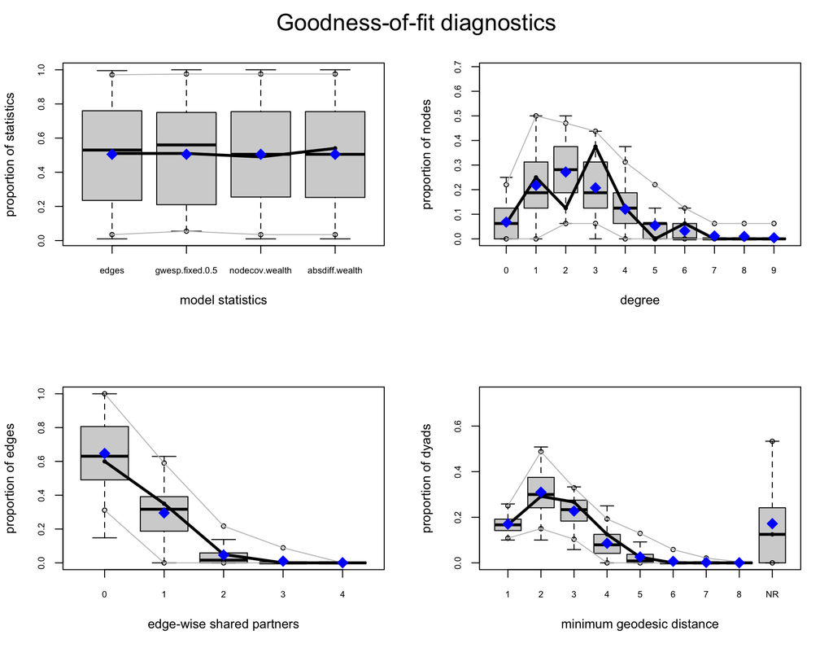

```r
par(mfrow = c(2, 2))
plot(gof_wealth)
```

In each panel, the **black line** is the observed statistic; the **boxplots** summarise the distribution across simulated networks; the **grey band** is the 95% confidence envelope. Observed values that fall comfortably within the envelope indicate a well-fitting model.

Compare GoF for the null model:

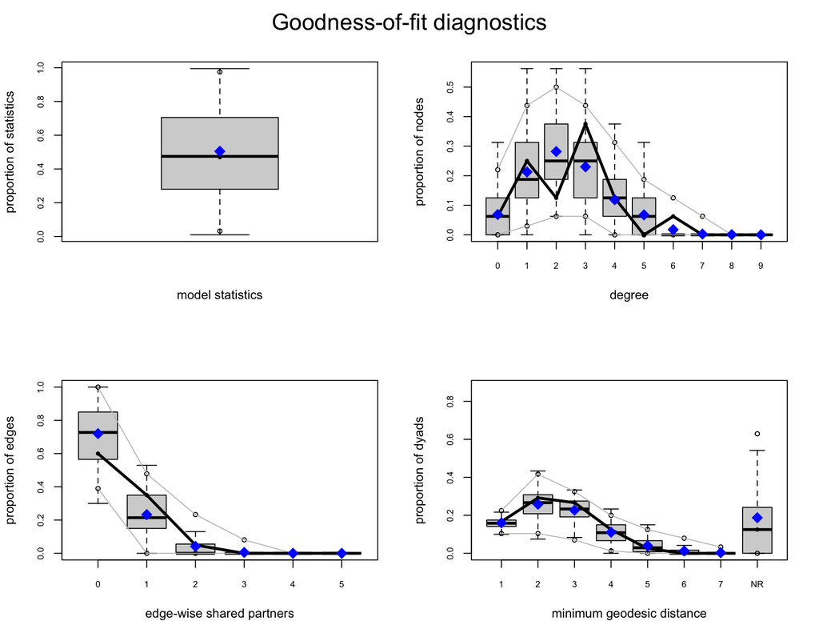

```r
gof_null <- gof(model_null)
par(mfrow = c(2, 2))
plot(gof_null)
```

## Interpreting ERGM Coefficients

ERGM parameters are on the **log-odds** scale for individual tie changes, *holding the rest of the network fixed*. This “change statistic” interpretation is subtle but important:

- The `edges` coefficient is the log-odds of a tie forming between two nodes when no other network statistics would change — i.e., the baseline propensity.
- The `gwesp` coefficient is the *additional* log-odds of a tie forming for each additional (geometrically weighted) shared partner the dyad has.
- The `nodecov("wealth")` coefficient is the additional log-odds contribution per unit increase in the *sum* of the two nodes’ wealth values.
- The `absdiff("wealth")` coefficient is the additional log-odds contribution per unit increase in the *absolute difference* in wealth.

```r
# Convert log-odds to odds ratios for easier interpretation
exp(coef(model_wealth))
```

```
          edges gwesp.fixed.0.5  nodecov.wealth  absdiff.wealth
     0.08191087      0.97600552      1.00465963      1.01136696
```

An odds ratio > 1 increases the probability of a tie; < 1 decreases it. For example, if `exp(coef(model_wealth)["gwesp.fixed.0.5"])` is 2.5, then each additional (weighted) shared partner multiplies the odds of a tie by 2.5.

## Summary and Key Takeaways

ERGMs provide a principled, statistically rigorous framework for asking whether network structure arises from:

- **Random chance** (the null/Bernoulli model),
- **Endogenous structural forces** like transitivity and degree-based effects (GWESP),
- **Exogenous nodal attributes** like wealth (nodecov, absdiff, nodematch), or
- **Some combination** of all of the above.

The workflow introduced here — **Specification → Estimation → MCMC Diagnostics → Goodness of Fit** — is the standard pipeline for any applied ERGM analysis. Never skip diagnostics: a model that has not converged or that fails GoF checks should not be interpreted, regardless of how tidy the summary table looks.

## Further Reading

- Lusher, Dean, Johan Koskinen, and Garry Robins. (2013). Exponential Random Graph Models for Social Networks : Theories, Methods, and Applications. Cambridge: Cambridge University Press.
- Rawlings, Craig M., Jeffrey A. Smith, James W. Moody, and Daniel McFarland. (2023) Network Analysis : Integrating Social Network Theory, Method, and Application with R. Cambridge: Cambridge University Press. https://inarwhal.github.io/NetworkAnalysisR-book/.
- Padgett, J. F., & Ansell, C. K. (1993). Robust action and the rise of the Medici. *American Journal of Sociology*, 98(6), 1259–1319.
- The `statnet` project: statnet.org — documentation, tutorials, and workshops.

Lusher, Dean, Johan Koskinen, and Garry Robins. 2013. *Exponential Random Graph Models for Social Networks : Theories, Methods, and Applications*. Structural Analysis in the Social Sciences ; 35. Cambridge: Cambridge University Press.

Rawlings, Craig M., Jeffrey A. Smith, James W. Moody, and Daniel McFarland. 2023. *Network Analysis : Integrating Social Network Theory, Method, and Application with R*. Structural Analysis in the Social Sciences. Cambridge: Cambridge University Press.